# loa

#### Prosper Loan data exploration

##### Preliminary wrangling

The prosper loan dataset is a financial dataset. Prosper is an American company that offers loans at low interest rates to the borrowers. The dataset is comprised of 81 variables and contains 113937 entries.

```python
#import packages
import numpy as np
import pandas as pd
import matplotlib.pyplot as plt
import seaborn as sb

import warnings
warnings.filterwarnings('ignore')

%matplotlib inline
```

```python
#load the dataset
df = pd.read_csv('prosperLoanData.csv')
```

```python
#shape of data
df.shape
```

```
(113937, 81)
```

```python
#columns of data
df.info()
```

```
<class 'pandas.core.frame.DataFrame'>
RangeIndex: 113937 entries, 0 to 113936
Data columns (total 81 columns):
 #   Column                               Non-Null Count   Dtype
---  ------                               --------------   -----
 0   ListingKey                           113937 non-null  object
 1   ListingNumber                        113937 non-null  int64
 2   ListingCreationDate                  113937 non-null  object
 3   CreditGrade                          28953 non-null   object
 4   Term                                 113937 non-null  int64
 5   LoanStatus                           113937 non-null  object
 6   ClosedDate                           55089 non-null   object
 7   BorrowerAPR                          113912 non-null  float64
 8   BorrowerRate                         113937 non-null  float64
 9   LenderYield                          113937 non-null  float64
```

[output cut: 73 more lines]

```python
#first 5 rows
df.head(5)
```

|  | ListingKey | ListingNumber | ListingCreationDate | CreditGrade | Term | LoanStatus | ClosedDate | BorrowerAPR | BorrowerRate | LenderYield | ... | LP_ServiceFees | LP_CollectionFees | LP_GrossPrincipalLoss | LP_NetPrincipalLoss | LP_NonPrincipalRecoverypayments | PercentFunded | Recommendations | InvestmentFromFriendsCount | InvestmentFromFriendsAmount | Investors |
| --- | --- | --- | --- | --- | --- | --- | --- | --- | --- | --- | --- | --- | --- | --- | --- | --- | --- | --- | --- | --- | --- |
| 0 | 1021339766868145413AB3B | 193129 | 2007-08-26 19:09:29.263000000 | C | 36 | Completed | 2009-08-14 00:00:00 | 0.16516 | 0.1580 | 0.1380 | ... | -133.18 | 0.0 | 0.0 | 0.0 | 0.0 | 1.0 | 0 | 0 | 0.0 | 258 |
| 1 | 10273602499503308B223C1 | 1209647 | 2014-02-27 08:28:07.900000000 | NaN | 36 | Current | NaN | 0.12016 | 0.0920 | 0.0820 | ... | 0.00 | 0.0 | 0.0 | 0.0 | 0.0 | 1.0 | 0 | 0 | 0.0 | 1 |
| 2 | 0EE9337825851032864889A | 81716 | 2007-01-05 15:00:47.090000000 | HR | 36 | Completed | 2009-12-17 00:00:00 | 0.28269 | 0.2750 | 0.2400 | ... | -24.20 | 0.0 | 0.0 | 0.0 | 0.0 | 1.0 | 0 | 0 | 0.0 | 41 |
| 3 | 0EF5356002482715299901A | 658116 | 2012-10-22 11:02:35.010000000 | NaN | 36 | Current | NaN | 0.12528 | 0.0974 | 0.0874 | ... | -108.01 | 0.0 | 0.0 | 0.0 | 0.0 | 1.0 | 0 | 0 | 0.0 | 158 |
| 4 | 0F023589499656230C5E3E2 | 909464 | 2013-09-14 18:38:39.097000000 | NaN | 36 | Current | NaN | 0.24614 | 0.2085 | 0.1985 | ... | -60.27 | 0.0 | 0.0 | 0.0 | 0.0 | 1.0 | 0 | 0 | 0.0 | 20 |

5 rows × 81 columns

```python
df.describe()
```

|  | ListingNumber | Term | BorrowerAPR | BorrowerRate | LenderYield | EstimatedEffectiveYield | EstimatedLoss | EstimatedReturn | ProsperRating (numeric) | ProsperScore | ... | LP_ServiceFees | LP_CollectionFees | LP_GrossPrincipalLoss | LP_NetPrincipalLoss | LP_NonPrincipalRecoverypayments | PercentFunded | Recommendations | InvestmentFromFriendsCount | InvestmentFromFriendsAmount | Investors |
| --- | --- | --- | --- | --- | --- | --- | --- | --- | --- | --- | --- | --- | --- | --- | --- | --- | --- | --- | --- | --- | --- |
| count | 1.139370e+05 | 113937.000000 | 113912.000000 | 113937.000000 | 113937.000000 | 84853.000000 | 84853.000000 | 84853.000000 | 84853.000000 | 84853.000000 | ... | 113937.000000 | 113937.000000 | 113937.000000 | 113937.000000 | 113937.000000 | 113937.000000 | 113937.000000 | 113937.000000 | 113937.000000 | 113937.000000 |
| mean | 6.278857e+05 | 40.830248 | 0.218828 | 0.192764 | 0.182701 | 0.168661 | 0.080306 | 0.096068 | 4.072243 | 5.950067 | ... | -54.725641 | -14.242698 | 700.446342 | 681.420499 | 25.142686 | 0.998584 | 0.048027 | 0.023460 | 16.550751 | 80.475228 |
| std | 3.280762e+05 | 10.436212 | 0.080364 | 0.074818 | 0.074516 | 0.068467 | 0.046764 | 0.030403 | 1.673227 | 2.376501 | ... | 60.675425 | 109.232758 | 2388.513831 | 2357.167068 | 275.657937 | 0.017919 | 0.332353 | 0.232412 | 294.545422 | 103.239020 |
| min | 4.000000e+00 | 12.000000 | 0.006530 | 0.000000 | -0.010000 | -0.182700 | 0.004900 | -0.182700 | 1.000000 | 1.000000 | ... | -664.870000 | -9274.750000 | -94.200000 | -954.550000 | 0.000000 | 0.700000 | 0.000000 | 0.000000 | 0.000000 | 1.000000 |
| 25% | 4.009190e+05 | 36.000000 | 0.156290 | 0.134000 | 0.124200 | 0.115670 | 0.042400 | 0.074080 | 3.000000 | 4.000000 | ... | -73.180000 | 0.000000 | 0.000000 | 0.000000 | 0.000000 | 1.000000 | 0.000000 | 0.000000 | 0.000000 | 2.000000 |
| 50% | 6.005540e+05 | 36.000000 | 0.209760 | 0.184000 | 0.173000 | 0.161500 | 0.072400 | 0.091700 | 4.000000 | 6.000000 | ... | -34.440000 | 0.000000 | 0.000000 | 0.000000 | 0.000000 | 1.000000 | 0.000000 | 0.000000 | 0.000000 | 44.000000 |
| 75% | 8.926340e+05 | 36.000000 | 0.283810 | 0.250000 | 0.240000 | 0.224300 | 0.112000 | 0.116600 | 5.000000 | 8.000000 | ... | -13.920000 | 0.000000 | 0.000000 | 0.000000 | 0.000000 | 1.000000 | 0.000000 | 0.000000 | 0.000000 | 115.000000 |
| max | 1.255725e+06 | 60.000000 | 0.512290 | 0.497500 | 0.492500 | 0.319900 | 0.366000 | 0.283700 | 7.000000 | 11.000000 | ... | 32.060000 | 0.000000 | 25000.000000 | 25000.000000 | 21117.900000 | 1.012500 | 39.000000 | 33.000000 | 25000.000000 | 1189.000000 |

8 rows × 61 columns

##### What is the structure of your dataset?

> The dataset has 113,937 entries with 81 columns.

##### What are the main features of interest in your dataset?

In the dataset, I will be investigating what influences loan performance in association with borrowers and lenders.

##### What features in the dataset do you think will help support your investigstion into your feature(s) of interest?

1. Term - The length of the loan expressed in months
2. BorrowerRate - The Borrower's interest rate for this loan
3. ProsperRating (Alpha) - The prosper rating assigned at the time the listing was created between AA-HR. Applicable for loas originated after July 2009
4. StatedMonthlyIncome - The monthly income the borrower stated at the time the listing was created
5. EmploymentStatus - The employmentstatus of the borrower at the time the listing is created.
6. EstimatedReturn - The estimated return assigned to the listing at the time it was created.
7. LoanOriginalAmount - The origination amount of the loan

##### Term

> Begin by getting a closer look at the feature of interests begining with the estimated returns

```python
df['Term'].describe()
```

```
count    113937.000000
mean         40.830248
std          10.436212
min          12.000000
25%          36.000000
50%          36.000000
75%          36.000000
max          60.000000
Name: Term, dtype: float64
```

> There seems to be no missing values in the column. The range is from 12-60.

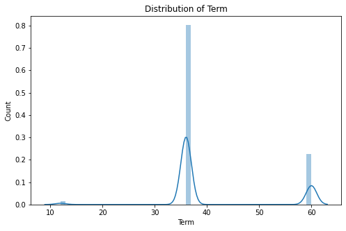

```python
#histogram plot
plt.figure(figsize= [8,5])
sb.distplot(df.Term)
plt.xlabel('Term')
plt.ylabel('Count')
plt.title('Distribution of Term')
```

It seems most loans have a term of 36 months followed by 60 months and 12 months

##### Borrower Rate

```python
df['BorrowerRate'].describe()
```

```
count    113937.000000
mean          0.192764
std           0.074818
min           0.000000
25%           0.134000
50%           0.184000
75%           0.250000
max           0.497500
Name: BorrowerRate, dtype: float64
```

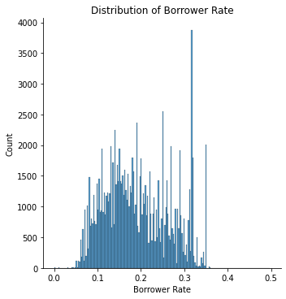

```python
#histogram plot
plt.figure(figsize = [8,5])
sb.displot(df.BorrowerRate, kde = False, bins = 200)
plt.xlabel('Borrower Rate')
plt.ylabel('Count')
plt.title('Distribution of Borrower Rate')
```

##### ProsperRating (Alpha)

```python
df['ProsperRating (Alpha)'].describe()
```

```
count     84853
unique        7
top           C
freq      18345
Name: ProsperRating (Alpha), dtype: object
```

```python
df['ProsperRating (Alpha)'].value_counts()
```

```
C     18345
B     15581
A     14551
D     14274
E      9795
HR     6935
AA     5372
Name: ProsperRating (Alpha), dtype: int64
```

```python
df['ProsperRating (Alpha)'].isna().sum()
```

```
29084
```

```python
df['CreditGrade'].describe()
```

```
count     28953
unique        8
top           C
freq       5649
Name: CreditGrade, dtype: object
```

```python
df['CreditGrade'].value_counts()
```

```
C     5649
D     5153
B     4389
AA    3509
HR    3508
A     3315
E     3289
NC     141
Name: CreditGrade, dtype: int64
```

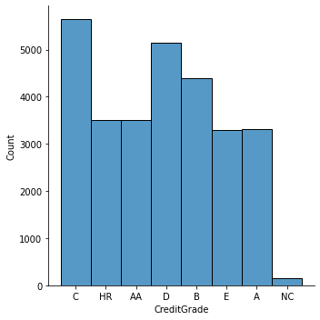

```python
sb.displot(df['CreditGrade'])
```

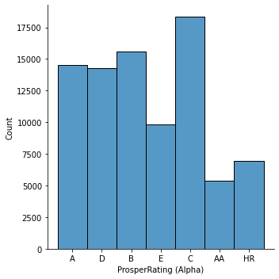

```python
sb.displot(df['ProsperRating (Alpha)'])
```

Prosper changed Credit Grade to Prosper Rating after 2009, that is why Prosper Rating is missing some values. We will merge credit grade with prosper rating.

```python
#merge NC and HR
df['CreditGrade'].replace(['NC', 'HR'], 'E', inplace=True)

#handle null values
df['CreditGrade'].fillna("", inplace=True)
df['ProsperRating (Alpha)'].fillna("", inplace=True)

#merge credit ratings
df['ProsperRatingMerged'] = df['ProsperRating (Alpha)'] + df['CreditGrade']

#drop rows
df = df.query('ProsperRatingMerged != ""')

#value count
df['ProsperRatingMerged'].value_counts()
```

```
C     23994
B     19970
D     19427
A     17866
E     16733
AA     8881
HR     6935
Name: ProsperRatingMerged, dtype: int64
```

```python
df['ProsperRatingMerged'].describe()
```

```
count     113806
unique         7
top            C
freq       23994
Name: ProsperRatingMerged, dtype: object
```

```python
#convert to ordinal type
ordinal_rates = ['AA', 'A', 'B', 'C', 'D', 'E']
ordered_ordinal = pd.api.types.CategoricalDtype(ordered=True, categories=ordinal_rates)
df['ProsperRatingMerged'] = df['ProsperRatingMerged'].astype(ordered_ordinal)
```

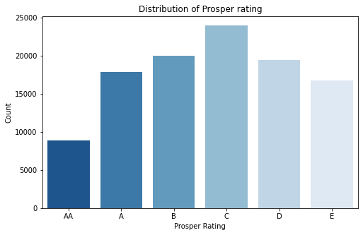

```python
plt.figure(figsize=[8,5])
sb.countplot(data = df, x = 'ProsperRatingMerged', palette='Blues_r')
plt.xlabel('Prosper Rating')
plt.ylabel('Count')
plt.title('Distribution of Prosper rating')
```

##### Stated Monthly Income

```python
df['StatedMonthlyIncome'].describe()
```

```
count    1.139370e+05
mean     5.608026e+03
std      7.478497e+03
min      0.000000e+00
25%      3.200333e+03
50%      4.666667e+03
75%      6.825000e+03
max      1.750003e+06
Name: StatedMonthlyIncome, dtype: float64
```

```python
df['StatedMonthlyIncome'].value_counts()
```

```
4166.666667     3526
5000.000000     3389
3333.333333     2917
3750.000000     2428
5416.666667     2374
                ...
7069.916667        1
4266.333333        1
2211.750000        1
7032.916667        1
18756.000000       1
Name: StatedMonthlyIncome, Length: 13502, dtype: int64
```

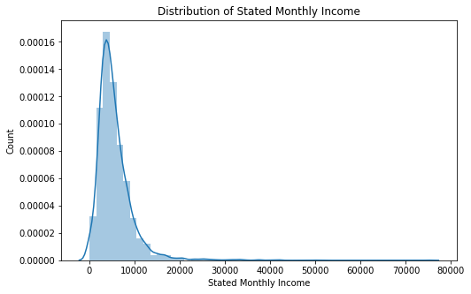

```python
#histogram plot
plt.figure(figsize = [8,5])
sb.distplot(df.StatedMonthlyIncome.head(5000))
plt.xlabel('Stated Monthly Income')
plt.ylabel('Count')
plt.title('Distribution of Stated Monthly Income')
```

```python
df['StatedMonthlyIncome'].isna().sum()
```

```
0
```

The Stated Monthly Income does not have missing values. The range is from 0-1.75e+06. The distribution is skewed to the right.

##### Employment status

The Employment status of the borrower at the time they created the listing.

```python
df['EmploymentStatus'].describe()
```

```
count       111682
unique           8
top       Employed
freq         67322
Name: EmploymentStatus, dtype: object
```

```python
df['EmploymentStatus'].value_counts()
```

```
Employed         67322
Full-time        26355
Self-employed     6134
Not available     5347
Other             3806
Part-time         1088
Not employed       835
Retired            795
Name: EmploymentStatus, dtype: int64
```

```python
#convert to ordinal type
ordinal_employment = ['Employed', 'Full-time', 'Self-employed', 'Not available', 'Other', 'Part-time', 'Not employed', 'Retired']
ordered_employment = pd.api.types.CategoricalDtype(ordered=True, categories=ordinal_employment)
df['EmploymentStatusNumbered'] = df['EmploymentStatus'].astype(ordered_employment)
```

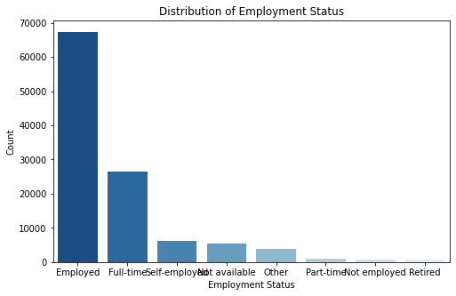

```python
plt.figure(figsize=[8,5])
sb.countplot(data = df, x = 'EmploymentStatusNumbered', palette='Blues_r')
plt.xlabel('Employment Status')
plt.ylabel('Count')
plt.title('Distribution of Employment Status')
```

The employment status feature has 8 unique values with Employed being the top followed by full-time and self-employed.

##### Estimated Returns

The estimated return assigned to the listing at the time it was created. Estimated return is the difference between the Estimated Effective Yield and the Estimated loss rate.

```python
df['EstimatedReturn'].describe()
```

```
count    84853.000000
mean         0.096068
std          0.030403
min         -0.182700
25%          0.074080
50%          0.091700
75%          0.116600
max          0.283700
Name: EstimatedReturn, dtype: float64
```

```python
df['EstimatedReturn'].isna().sum()
```

```
29084
```

```python
#drop null
df['EstimatedReturn'].dropna(axis = 0, inplace = True)
```

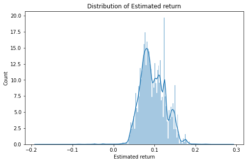

```python
#histogram plot
plt.figure(figsize = [8,5])
sb.distplot(df.EstimatedReturn, bins = 200)
plt.xlabel('Estimated return')
plt.ylabel('Count')
plt.title('Distribution of Estimated return')
```

> The feature of Estimated return appears to have a range of -18%-28%. The distribution is skewed to the right. The quartiles lie from 7%, 9& and 11%.

##### Loan Original Amount

> This is the original loan amount.

```python
df['LoanOriginalAmount'].describe()
```

```
count    113937.00000
mean       8337.01385
std        6245.80058
min        1000.00000
25%        4000.00000
50%        6500.00000
75%       12000.00000
max       35000.00000
Name: LoanOriginalAmount, dtype: float64
```

```python
df['LoanOriginalAmount'].isna().sum()
```

```
0
```

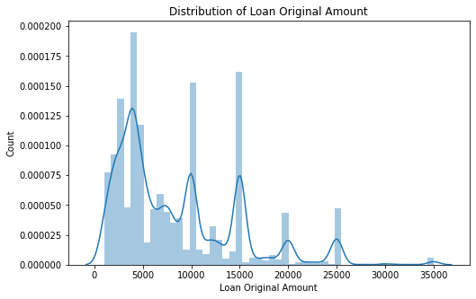

```python
#histogram plot
plt.figure(figsize = [8,5])
sb.distplot(df.LoanOriginalAmount)
plt.xlabel('Loan Original Amount')
plt.ylabel('Count')
plt.title('Distribution of Loan Original Amount')
```

> The Loan Original Amount feature does not have any missing values. The range is from 1000 to 35000. The distribution is skewed to the right.

##### Of the features you investigated, were there any unusual distributions? Did you perform any operations on the data to tidy, adjust, or change the form of the data? If so, why did you do this?

To tidy the data, I removed null values from EstimatedReturn. I did this in order to have better data when plotting histograms in order to have correct values. I adjusted and changed the ProsperRating by merging with CreditGrade, this enabled to cover all entries pre-2009 and post-2009.

##### Bivariate Exploration

```python
#categorical & numeric variables
categorical_variables = ['ProsperRatingMerged', 'EmploymentStatus']
numeric_variables = ['Term', 'BorrowerRate', 'StatedMonthlyIncome', 'EstimatedReturn', 'LoanOriginalAmount']
```

[figure not shown]

```python
#pair grid
pg = sb.PairGrid(data = df, vars = numeric_variables, aspect = 1.25)
pg = pg.map_diag(plt.hist, bins = 50)
pg.map_offdiag(plt.scatter, alpha=1/8)

#set axis limits
pg.axes[0,0].set_ylim(0,1)
pg.axes[0,0].set_xlim(-.1,1)
pg.axes[0,1].set_xlim(-1.1,2)
pg.axes[0,2].set_xlim(0,.2)

pg.fig.suptitle('Matrix plot of Term, Borrower Rate, Stated Monthly Income and ListingCategory')
pg.fig.subplots_adjust(top = .95)
```

There is a correlation between Borrower rate and Estimated Return

There is no correlation between StatedMonthlyIncome ad Estimated Return

There is no correlation between StatedMonthlyIncome and BorrowerRate

There is a correlation between EstimatedReturn and BorrowerRate

There is a correlation between EstimatedReturn and Borrower rate

##### Employment status and ProsperRating

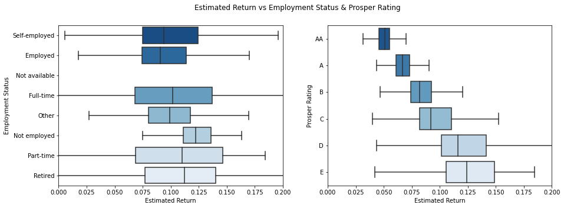

```python
#boxplot
plt.figure(figsize=[15,5])

plt.subplot(1,2,1)
base_color = sb.color_palette()[0]
sb.boxplot(data=df, y='EmploymentStatus', x='EstimatedReturn', palette='Blues_r',showfliers=False)
plt.xlim(0,.2)
plt.ylabel('Employment Status')
plt.xlabel('Estimated Return')

plt.subplot(1,2,2)
base_color = sb.color_palette()[0]
sb.boxplot(data = df, y='ProsperRatingMerged', x='EstimatedReturn', palette='Blues_r',showfliers=False)
plt.xlim(0,.2)
plt.ylabel('Prosper Rating')
plt.xlabel('Estimated Return')

plt.suptitle('Estimated Return vs Employment Status & Prosper Rating')
```

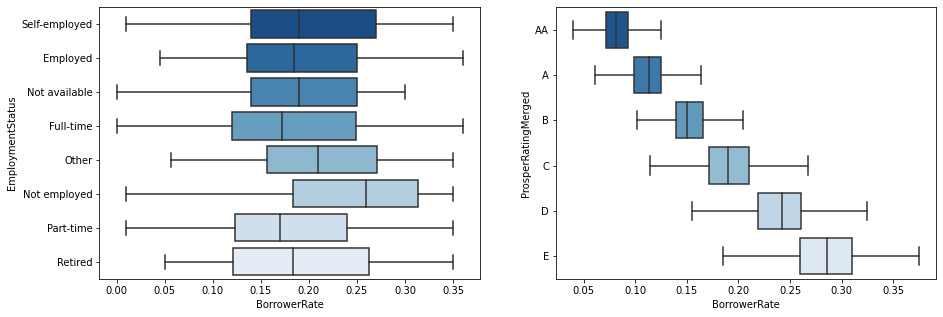

```python
#boxplots
plt.figure(figsize=[15,5])

plt.subplot(1,2,1)
base_color=sb.color_palette()[0]
sb.boxplot(data=df, y='EmploymentStatus', x='BorrowerRate', palette='Blues_r', showfliers = False)

plt.subplot(1,2,2)
base_color= sb.color_palette()[0]
sb.boxplot(data=df, y='ProsperRatingMerged', x='BorrowerRate', palette='Blues_r',showfliers=False)
```

##### Prosper Rating and Employment Status

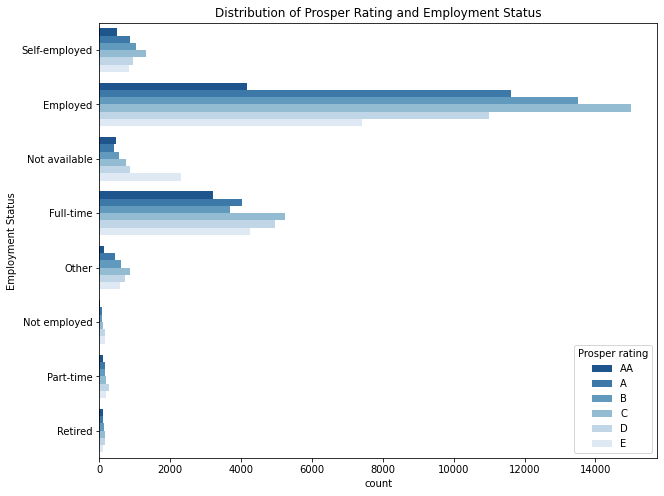

```python
plt.figure(figsize=[10,8])

ax = sb.countplot(data=df, y='EmploymentStatus', hue='ProsperRatingMerged', palette='Blues_r')
ax.legend(title='Prosper rating')
plt.title('Distribution of Prosper Rating and Employment Status')
plt.ylabel('Employment Status')
```

From the chart above, we can see that employed people make the most people who take loans. Most of the employed people have a rating of C. They also have the most members with a ratong of AA followed by Full time and Self-employed.

This would make sense because employed people have a consistent income, lenders are guranteed that the loans taken by employed people will be paid.

##### Talk about some of the relationships you observed in this part of the investigation. How did the feature(s) of interest vary with other features in the datasrt? Did you observe any interesting relationships between the other features (not the main feature(s) of interest)?

From the chart above, we can see that employed people make the most people who take loans. Most of the employed people have a rating of C. They also have the most members with a ratong of AA followed by Full time and Self-employed. This would make sense because employed people have a consistent income, lenders are guranteed that the loans taken by employed people will be paid.

##### Multivariate Exploration

To investigate the relationship between Employment status, Prosper rating and Estimated returns

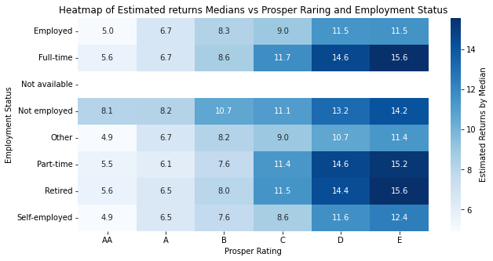

```python
#heat map
plt.figure(figsize = [10,5])

m_exp = df.groupby(['ProsperRatingMerged', 'EmploymentStatus']).median()['EstimatedReturn']*100
m_exp = m_exp.reset_index(name='EstimatedReturnMedian')
m_exp = m_exp.pivot(index = 'EmploymentStatus', columns = 'ProsperRatingMerged', values = 'EstimatedReturnMedian')

sb.heatmap(m_exp, annot=True, fmt='.1f', cmap='Blues', cbar_kws={'label':'Estimated Returns by Median'})
plt.xlabel('Prosper Rating')
plt.ylabel('Employment Status')
plt.title('Heatmap of Estimated returns Medians vs Prosper Raring and Employment Status')
```

Another trend we can observe from the chart above is that, People who work full time have the highest estimated return despite having the worst prosper rating.

Despite what we have observed earlier, retired people has the least amount of people taking loans but they have the highest estimated return and have the worst prosper rating.

In the B category people who are not employed also have the highest estimated return, while people who work full time have the highest return in the C category.

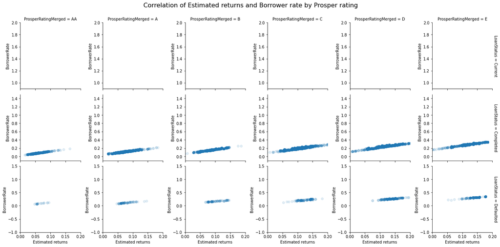

```python
#scatter plot
m = sb.FacetGrid(data = df, col = 'ProsperRatingMerged', row_order=['Current','Completed','Defaulted'], row = 'LoanStatus', margin_titles=True, xlim=(0,.2), sharey=False)
m.map(plt.scatter, 'EstimatedReturn', 'BorrowerRate',alpha=1/8)

#set different y axes for different loan statuses
for i, ax in enumerate(m.axes.flat):
    if i < 6:
        ax.set_ylim(.9,2)
    elif i < 12:
        ax.set_ylim(-.1, 1.5)
    else:
        ax.set_ylim(-1, 1.5)

m.set(xlabel = 'Estimated returns', ylabel = 'BorrowerRate')

m.fig.suptitle('Correlation of Estimated returns and Borrower rate by Prosper rating', size=16)
m.fig.subplots_adjust(top=.9)
```

##### Talk about some of the relationships you observed in this part of the investigation. Were there features that strengthened each other in terms of looking at your feature(s) of interest? Were there any interesting or surprising interactions between features?

For the completed loans it seems that estimated returns increase as borrower rate increases while for the defaulted loans it seems that estimated returns increase with increase borrower rate increase.